# Bristol’s Air Quality in the COVID-19 Lockdown

Steve Crawshaw

2020-11-26

This brief report summarises the air quality impact of the lockdown policy on air quality measurements in Bristol.

## Introduction

This report summarises changes to ambient air quality, represented by concentrations of regulated pollutants, that have occurred during the COVID-19 crisis. Bristol City Council continued to monitor air quality throughout lockdown as this work was classed by the government as an essential activity.

Traffic levels declined rapidly from slightly before lockdown leading to a clear reduction in emissions of key pollutants. This is apparent for roadside and background sites.

Air quality changed during the period, but the changes in air quality characterised by comparisons of *raw* data between two periods cannot be solely attributed to the lockdown measures, because weather and other variables strongly influence ambient air quality. In order to account for the influence of weather and other covariates, a statistical modelling approach has been adopted which can remove the effect of the weather and identify the changes in concentrations which would arise if meteorological conditions and temporal effects are held constant. This approach can be used to ascribe the changes in air quality to lockdown measures with more certainty than simply by comparing raw data between two periods.

## Summary of changes

The comparison of raw data between 2019 and 2020 was for the period 2019-03-25 to 2019-11-01 and 2020-03-24 to 2020-10-31.

Analysis of air quality data from Bristol City Council’s continuous air monitoring network comparing the lockdown period in 2020 to the same period in 2019 shows a significant change in nitrogen dioxide (NO<sub>2</sub>), a traffic pollutant, of a maximum -76% as a weekly average. Reductions in NOx (oxides of nitrogen), which can be considered a surrogate for direct exhaust emissions, fell even further with a maximum mean weekly change of -86%. These changes cannot be attributed solely to the lockdown measures because of the effect of weather and the small effect of changes in the vehicle fleet between the two comparison periods.

Measures of particulate matter (PM) - PM<sub>10</sub> and PM<sub>2.5</sub> also fell but the reduction was less. This is because the local contribution to ambient PM is a small part of the total. There are significant regional and background components present which are unaffected by the lockdown measures. For PM<sub>10</sub> the roadside increment in 2019 was 27% when comparing a background and roadside site in the central city.

Ozone (O<sub>3</sub>) rose in the first lockdown when compared to the baseline period. This is expected because as NOx declines, less ozone is chemically reduced in the photochemical reaction between these two species and hence concentrations of ozone may rise. Unusually sunny weather also contributed to the higher than usual levels of ozone.

Data from the [NO<sub>2</sub> diffusion tube network](https://opendata.bristol.gov.uk/explore/dataset/no2-diffusion-tube-data/map/?disjunctive.location&refine.year=2018&location=12,51.46856,-2.60587&basemap=jawg.streets), which gives greater spatial coverage than the continuous network has been analysed. The changes in measured nitrogen dioxide for each month where we have data are shown. There is typically around a 6 week delay between the end of the month where tubes have been exposed, to receiving the results.

All of Bristol’s air quality data are available through our [open data portal.](https://opendata.bristol.gov.uk/pages/air-quality-dashboard-new/map#air-quality-now)

## Traffic

Traffic flows started to decline when the first measures were announced on the 16th March. By the time full lockdown was operating (from 24th March), traffic flows had declined by more than 50% compared to normal levels. Data are from BCC’s Urban Traffic Control (UTC) system and represent smoothed daily mean speeds and total flows at routes or counters close to the continuous air quality monitoring sites.

It can be seen that traffic flows began to climb slowly again after the first week in April.

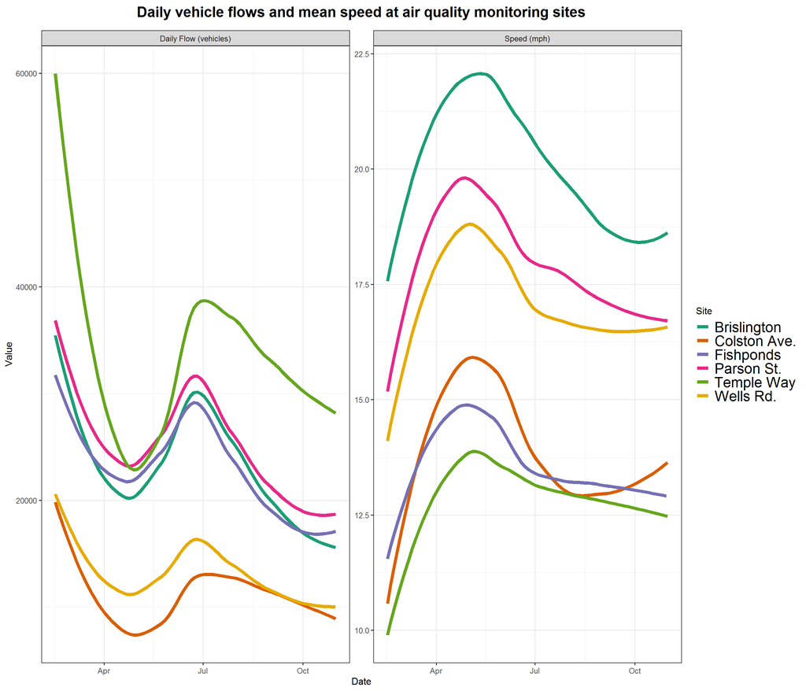

Fig 1. Daily traffic flows and speeds: 2020

Google and Apple are providing access to their mobility data during the COVID-19 lockdown. The chart below shows weekly trends in [mobility by sector for Bristol from Google’s dataset](https://opendata.bristol.gov.uk/explore/dataset/google_mobility_data/information/). The baseline for comparison is the median value, for the corresponding day of the week, during the 5-week period Jan 3 – Feb 6, 2020. The initial reaaduction in mobility for all sectors except residential is apparent. In this context the residential category includes deliveries to homes. There does seem to be a slight increase after the first week in April of non residential sector mobility and from mid - May there was a steep increase in mobility associated with use of parks.

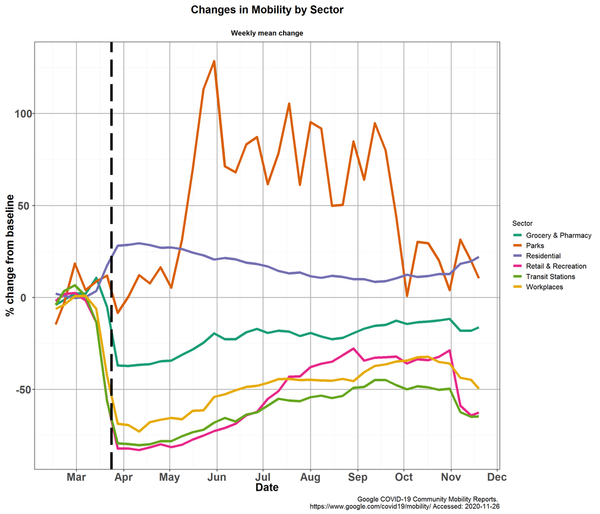

Fig 2. Mobility by sector: 2020

## Summary of changes by pollutant

The table below shows the maximum percentage changes of weekly mean concentrations aggregated by site and pollutant. Roadside sites have been selected as these are the most affected. The analysis compares weekly averages to the same week in the preceding year, i.e. 2019. While this does not take into account the effects of the weather on concentrations, it provides an indication of the extent of change and by using weekly means, noise that would be apparent when using a daily mean value is reduced. Bristol City Council’s data are ratified according to processes detailed with our [annual status reports](https://www.bristol.gov.uk/documents/20182/32675/Bristol+City+Council+2019+Air+Quality+Annual+Status+Report+ASR.pdf/62eeb142-ac59-ac08-148b-a1247e08b1db). Data from the national network sites (Bristol St. Pauls and Bristol Temple Way) are not fully ratified at the time of writing.

Maximum weekly change by pollutant and site

Compared to 2019

| Site ID | Site | Pollutant | Week beginning | Change |
| --- | --- | --- | --- | --- |
| 215 | Parson St. | NO<sub>2</sub> | 2020-08-24 | −55% |
| 215 | Parson St. | NOx | 2020-04-06 | −59% |
| 270 | Wells Road | NO<sub>2</sub> | 2020-04-20 | −51% |
| 270 | Wells Road | NOx | 2020-10-19 | −58% |
| 463 | Fishponds Road | NO<sub>2</sub> | 2020-03-23 | −75% |
| 463 | Fishponds Road | NOx | 2020-03-30 | −77% |
| 500 | Temple Way | NO<sub>2</sub> | 2020-07-06 | −76% |
| 500 | Temple Way | NOx | 2020-07-06 | −85% |
| 501 | Colston Avenue | NO<sub>2</sub> | 2020-04-20 | −76% |
| 501 | Colston Avenue | NOx | 2020-04-20 | −86% |

The chart below shows the weekly mean concentrations of NOx at sites in 2019 and 2020. Not all sites measure all pollutants. NOx is selected as this pollutant is most closely associated with traffic emissions.

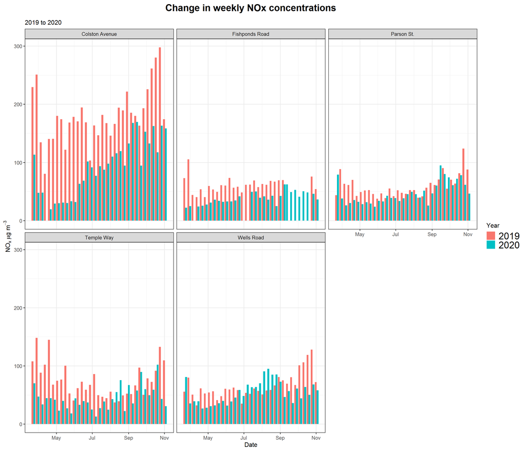

Fig 3. Weekly changes in mean NOx by site and year

## Locations of continuous monitoring sites

[interactive chart not shown]

Fig 4. Locations of current continuous monitoring sites

## Comparison with other cities

It is not possible to infer much meaning from the relative differences in changes between cities as there are a range of site - specific factors that could influence this, but the data are presented to show the national context.

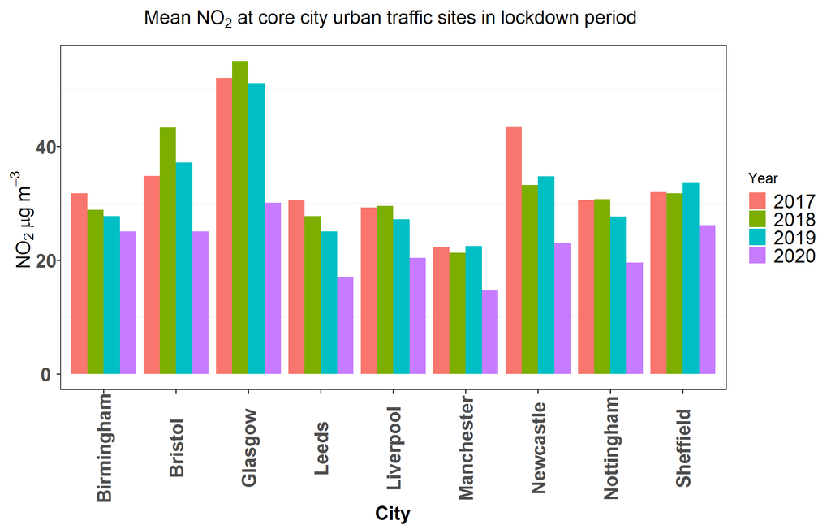

Fig 4. National comparison: nitrogen dioxide at urban traffic sites

## Changes in air quality at Bristol’s continuous monitoring sites

Bristol’s city centre site at [Colston Avenue](https://opendata.bristol.gov.uk/pages/aqcontinuoussites/?q=siteid:501) is the most polluted roadside site on the network and so is an interesting example of the reductions during the lockdown. The chart below shows weekly mean concentrations of NOx, NO<sub>2</sub> and PM<sub>10</sub> for the baseline and lockdown period. Operational issues between 9th April and 15th April mean that data is incomplete for this period.

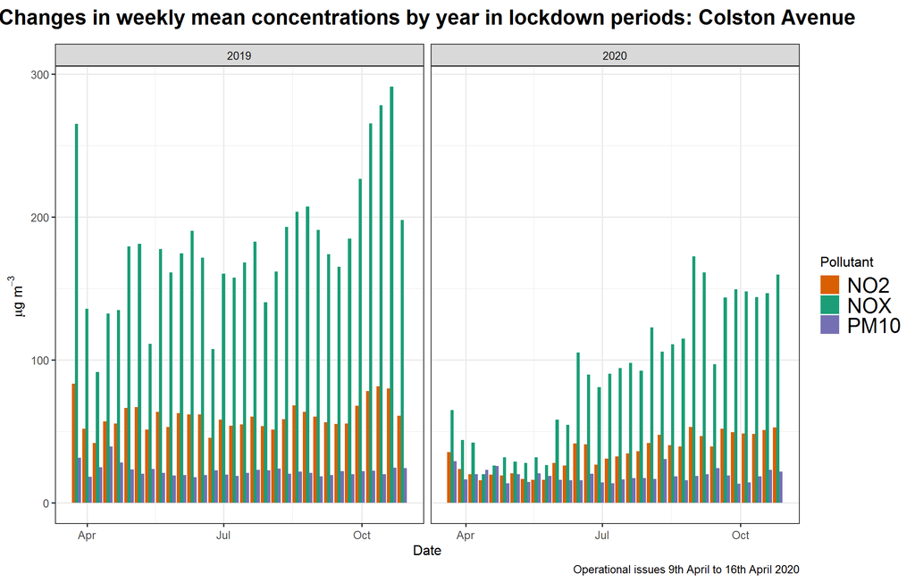

Fig 5. Chart of Colston Avenue site by pollutant

Other sites on the network show similar patterns. For the [Wells Road](https://opendata.bristol.gov.uk/pages/aqcontinuoussites/?q=siteid:270) site, the difference in concentrations between the two periods was not as pronounced as for Colston Avenue.

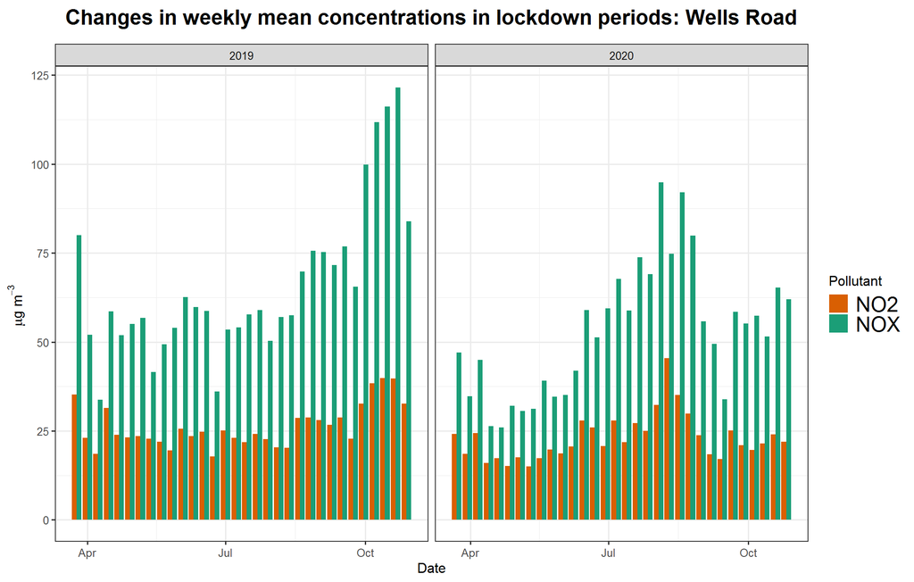

Fig 6. NOx and NO2: Wells Road

## Changes in nitrogen dioxide at diffusion tube sites

Diffusion tubes are used to monitor ambient nitrogen dioxide. Nitrogen dioxide from the air diffuses into a metal grid in the tube and the tubes are sent for analysis in a laboratory. Diffusion tubes are placed according to a monthly calendar specified by Defra and BCC’s diffusion tubes are exposed according to this calendar. April 2020 was the first complete month where tubes were entirely exposed under the lockdown measures.

The chart below shows that the difference in concentrations between 2019 and 2020 increased dramatically as the first lockdown took effect and diminished as lockdown measures were eased during the summer.

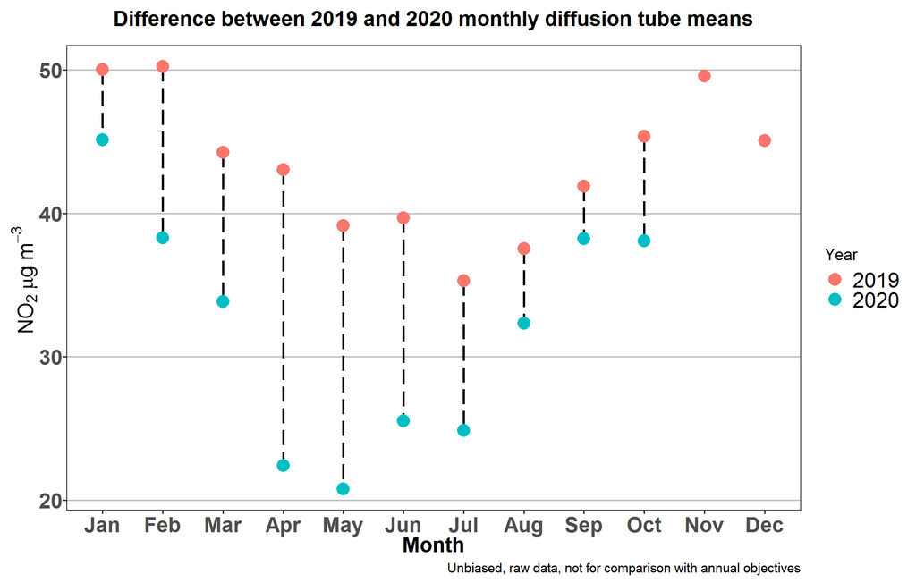

## Accounting for meteorology

Analysis of the wind speed and direction from [Bristol Lulsgate](https://opendata.bristol.gov.uk/explore/dataset/met-data-bristol-lulsgate/information/) show that although wind speeds from the NE quadrant were higher in the 2020 lockdown period than in the baseline period in 2019, it is unlikely that this can explain all of the dramatic reduction shown, as the wind from the dominant direction for this period will be somewhat polluted by other urban upwind emissions. Further de - weathering analysis is required to establish this with more certainty and is summarised in the following section.

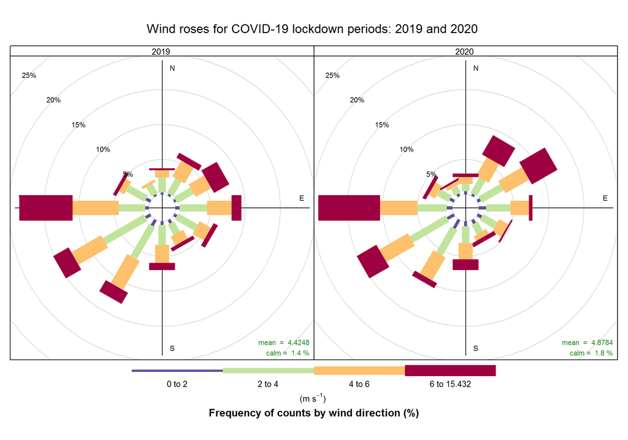

Fig 8. Wind roses for lockdown periods: Bristol Lulsgate

### De - weathering ambient air quality measurements

The deweather functions of the [openair package](https://cran.r-project.org/web/packages/openair/index.html) were used to remove the effect of the weather on concentrations of regulated pollutants measured by Bristol City Council’s and Defra’s monitoring sites in Bristol. The deweather package uses a boosted regression tree approach for modelling air quality data. This technique builds a statistical model of the air quality data and thereby takes account of the many complex interactions between variables as well as non-linear relationships between the variables.

Predictions of daily mean concentrations are derived from the modelled hourly means of data that are aggregated by site type. The accepted classifications of “Urban Background” (distant from busy road) and “Urban Traffic” (close to busy road) were used, as well as a classification of “City Centre” to cover the most polluted site, Colston Avenue, as this site represents the most polluted air in the city. Sites with a data capture less than 90% are not used in the analysis. The table below shows the classes for each of the sites analysed.

|  | Site | Classification |
| --- | --- | --- |
| 1 | AURN St Pauls | Urban Background |
| 2 | Brislington Depot | Urban Background |
| 3 | Colston Avenue | City Centre |
| 4 | Parson Street School | Urban Traffic |
| 5 | Temple Way | Urban Traffic |
| 6 | Wells Road | Urban Traffic |

Table 2. Sites aggregated for model analysis

The chart shown below is the predicted “de - weathered” concentrations of three pollutants grouped into site types. The removal of the influence of the weather indicates that the reductions in measurements of traffic pollutants are probably not due solely to the weather. Reductions in traffic emissions due to COVID-19 lockdown measures is the likely explanation.

For NO<sub>2</sub> it is noticeable that at the city centre site (Colston Avenue) concentrations started to decline around the 16th March, and continued to decline further in the days immediately following lockdown on the 24th March. The post - lockdown decline was also apparent in the urban traffic and urban background site classes. A small increase in NO<sub>2</sub> at urban traffic and urban background sites was seen around 8th - 12th of April. This could be explained by a regional pollution episode that also increased PM<sub>10</sub> concentrations during the same period. Unfortunately operational issues at the city centre site mean that data was unavailable from the 9th April to the 15th April.

PM<sub>10</sub> concentrations did decline in the immediate post - lockdown period but then rose steeply during the pollution episode over Easter weekend. The boosted regression tree model used in the de - weathering process take into account wind speed and direction but cannot account for elevated pollutant levels in the incoming air and hence are unable to remove the effect of regional pollution episodes such as the one that occurred at this time.

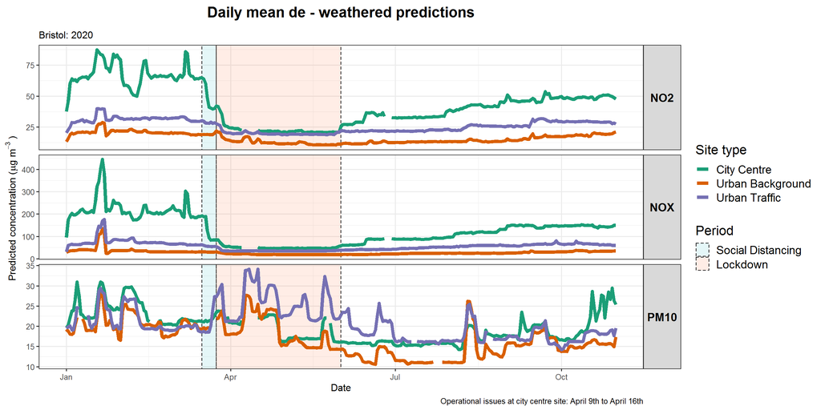

Fig 8. Deweathered chart by site class

The de - weathering process can also be applied to individual sites. The chart below shows how the de-weathered daily predictions vary from the mean levels for traffic pollutants for 2020 for each site. It is clear that from the date of lockdown, significant reductions have ocurred at all sites for NOx and NO<sub>2</sub> and that these reductions are not primarily driven by weather. It can be seen that deweathered concentrations start to rise from mid June.

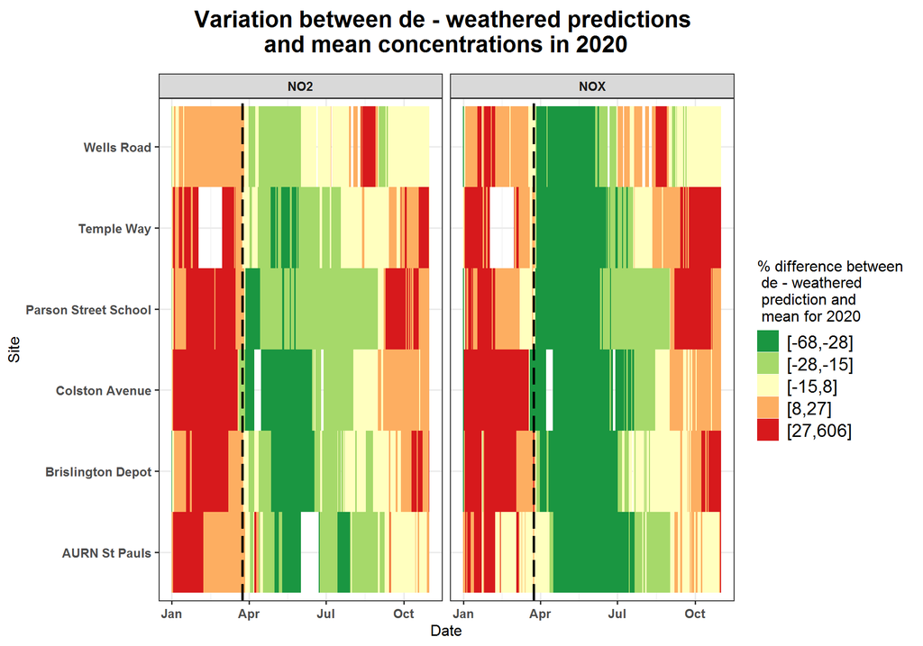

Fig 9. Deweathered chart by site: NOx and NO2

The predicted changes in the deweathered NOx and NO<sub>2</sub> concentrations are summarised in the table below. The comparison is between the period 2020-01-01 - 2020-03-23 and 2020-03-24 - 2020-10-31. It is clear that Colston Avenue experienced the largest drop in NO<sub>2</sub> and NOx concentrations.

| Site | NO2 Change % | NOx Change % |
| --- | --- | --- |
| AURN St Pauls | -37 | -44 |
| Brislington Depot | -30 | -38 |
| Colston Avenue | -46 | -55 |
| Parson Street School | -30 | -34 |
| Temple Way | -29 | -39 |
| Wells Road | -17 | -25 |

Table 3. Summary statistics for de - weathered NOx and NO2 concentrations

Plotting the weekly mean concentrations of the traffic pollutants NOx and NO<sub>2</sub> shows the effect of lockdown rules on weekly concentrations by controlling for the effect of the weather. It can be seen from the plot below that concentrations remained low throughout May despite some evidence that traffic levels are climbing since mid April. There is some evidence of rising concentrations towards the end of June, particularly at Colston Avenue.

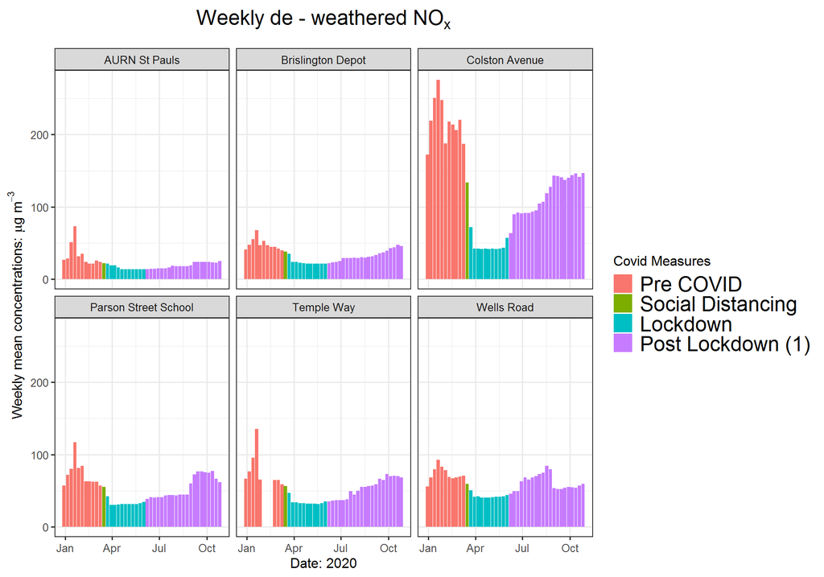